# Notebook

Hola Rubintel!

Soy **Patricio Requena** 👋. Es un placer ser el revisor de tu proyecto el día de hoy!

Revisaré tu proyecto detenidamente con el objetivo de ayudarte a mejorar y perfeccionar tus habilidades. Durante mi revisión, identificaré áreas donde puedas hacer mejoras en tu código, señalando específicamente qué y cómo podrías ajustar para optimizar el rendimiento y la claridad de tu proyecto. Además, es importante para mí destacar los aspectos que has manejado excepcionalmente bien. Reconocer tus fortalezas te ayudará a entender qué técnicas y métodos están funcionando a tu favor y cómo puedes aplicarlos en futuras tareas.

**Recuerda que al final de este notebook encontrarás un comentario general de mi parte**, empecemos!

Encontrarás mis comentarios dentro de cajas verdes, amarillas o rojas, ⚠️ **por favor, no muevas, modifiques o borres mis comentarios** ⚠️:

**Comentario del revisor** Si todo está perfecto.

**Comentario del revisor** Si tu código está bien pero se puede mejorar o hay algún detalle que le hace falta.

**Comentario del revisor** Si de pronto hace falta algo o existe algún problema con tu código o conclusiones.

Puedes responderme de esta forma:

**Respuesta del estudiante**

Film Junky Union, una nueva comunidad vanguardista para los aficionados de las películas clásicas, está desarrollando un sistema para filtrar y categorizar reseñas de películas. Tu objetivo es entrenar un modelo para detectar las críticas negativas de forma automática. Para lograrlo, utilizarás un conjunto de datos de reseñas de películas de IMDB con leyendas de polaridad para construir un modelo para clasificar las reseñas positivas y negativas. Este deberá alcanzar un valor F1 de al menos 0.85.

# 🎬 Film Junky Union - Análisis de Sentimientos en Reseñas de Películas 🍿

## 📜 Descripción del Proyecto:

**Film Junky Union**, una nueva comunidad vanguardista para los aficionados de las películas clásicas, está desarrollando un sistema para filtrar y categorizar reseñas de películas. Tu objetivo es entrenar modelos para detectar las críticas negativas de forma automática. Para lograrlo, utilizarás un conjunto de datos de reseñas de películas de IMDB con leyendas de polaridad para construir modelos que clasifiquen las reseñas como positivas o negativas. Se espera que estos modelos alcancen un valor F1 de al menos 0.85.

## 🧠 Modelos a Implementar:

1. **Modelo 0** - DummyClassifier (Constante) 🤖
2. **Modelo 1** - NLTK, TF-IDF y Logistic Regression 📊
3. **Modelo 2** - Random Forest 🌳
4. **Modelo 3** - spaCy, TF-IDF y Logistic Regression 📈
5. **Modelo 4** - spaCy, TF-IDF y LightGBM 💡
6. **Modelo 9** - BERT y LightGBMClassifier 🤖💡

# Descripcipción del proyecto

**Comentario del revisor (1ra Iteracion)**

Esta es una introducción bastante buena! Mantén esta práctica de redactar una sección introductoria del proyecto ya que da más visibilidad de lo que se hará para el que quiera replicar tu trabajo

```python
#!pip install --upgrade tqdm && jupyter labextension install @jupyter-widgets/jupyterlab-manager && pip install --upgrade jupyter jupyterlab
```

## Inicialización

```python
# ----------------------------
# Celda 01: Importaciones y Configuraciones Iniciales
# ----------------------------

import os
import time
import math
import logging
from datetime import datetime
import warnings

# Importaciones de bibliotecas de terceros
import numpy as np
import pandas as pd
import matplotlib.pyplot as plt
import seaborn as sns
import nltk
from nltk.corpus import stopwords
from sklearn.preprocessing import StandardScaler, MinMaxScaler
from sklearn.impute import SimpleImputer
from sklearn.feature_extraction.text import TfidfVectorizer
from sklearn.linear_model import LogisticRegression
from sklearn.dummy import DummyClassifier
from sklearn.ensemble import RandomForestClassifier
from sklearn.metrics import (precision_recall_curve, roc_curve, roc_auc_score,
                             average_precision_score, accuracy_score, f1_score)
from sklearn.model_selection import train_test_split, GridSearchCV
import spacy
from lightgbm import LGBMClassifier
import torch
from transformers import BertTokenizer, BertModel, DistilBertTokenizer, DistilBertModel
from torch.utils.data import DataLoader, TensorDataset
import transformers
import joblib
from IPython.display import display, HTML
import ipywidgets as widgets
from tqdm.auto import tqdm

# Configuración de visualización para pandas y matplotlib
%matplotlib inline
plt.style.use('seaborn')
pd.set_option('display.max_columns', None)
pd.set_option('display.expand_frame_repr', False)
pd.set_option('display.max_rows', None)
pd.set_option('display.max_colwidth', None)
pd.set_option('display.precision', 2)
pd.set_option('display.float_format', '{:,.2f}'.format)
pd.set_option('display.width', 1000)
pd.set_option('display.show_dimensions', True)
pd.set_option('display.memory_usage', 'deep')
pd.set_option('display.large_repr', 'truncate')
pd.set_option('display.colheader_justify', 'center')

# Configuración de logging
logging.basicConfig(
    filename='sprint14.log',
    level=logging.INFO,
    format='%(asctime)s - %(levelname)s - %(message)s'
)

# Variables globales para seguimiento
error_occurred = False
celda_times = {}
start_time = time.time()

def manejar_excepciones_y_tiempo(mensaje=None, use_progress_bar=False):
    """
    Decorador para manejar excepciones, medir tiempo de ejecución y mostrar un mensaje personalizado.

    Args:
        mensaje (str): Mensaje descriptivo del propósito de la celda decorada.
        use_progress_bar (bool): Indica si se debe mostrar una barra de progreso.
    """
    def decorator(func):
        def wrapper(*args, **kwargs):
            global error_occurred
            celda_start_time = time.time()
            celda_nombre = mensaje if mensaje else f"Celda '{func.__name__}'"

            try:
                # Mostrar mensaje inicial
                display(HTML(f"""
                <div style="
                    border: 1px solid #2196F3;
                    background-color: #E3F2FD;
                    padding: 10px;
                    border-radius: 5px;
                    margin: 10px 0;
                    font-family: Arial, sans-serif;">
                    <strong>🔄 {celda_nombre} - Iniciando ejecución...</strong>
                </div>
                """))

                # Si se solicita, mostrar una barra de progreso
                if use_progress_bar:
                    with tqdm(total=100, desc=celda_nombre, bar_format='{l_bar}{bar}| {n_fmt}/{total_fmt}') as pbar:
                        kwargs['pbar'] = pbar  # Pasar pbar a la función
                        result = func(*args, **kwargs)
                else:
                    result = func(*args, **kwargs)

                elapsed_time = time.time() - celda_start_time
                celda_times[celda_nombre] = elapsed_time
                logging.info(f"✅ {celda_nombre} ejecutada con éxito en {elapsed_time:.2f} segundos.")

                # Mostrar notificación de éxito con estilo
                display(HTML(f"""
                <div style="
                    border: 1px solid #4CAF50;
                    background-color: #E8F5E9;
                    padding: 10px;
                    border-radius: 5px;
                    margin: 10px 0;
                    font-family: Arial, sans-serif;">
                    <strong>✅ {celda_nombre} - Ejecutada en {elapsed_time:.2f} segundos.</strong>
                </div>
                """))

                return result
            except Exception as e:
                error_occurred = True
                logging.error(f"❌ Error en {celda_nombre}: {str(e)}")
                display(HTML(f"""
                <div style="
                    border: 1px solid #F44336;
                    background-color: #FFEBEE;
                    padding: 10px;
                    border-radius: 5px;
                    margin: 10px 0;
                    font-family: Arial, sans-serif;">
                    <strong>❌ Error en {celda_nombre}: {str(e)}</strong>
                </div>
                """))
        return wrapper
    return decorator

def mostrar_notificacion(mensaje, tipo='info'):
    """
    Muestra una notificación estilizada en el notebook.

    Args:
        mensaje (str): El mensaje a mostrar.
        tipo (str): El tipo de notificación ('info', 'success', 'error', 'warning').
    """
    colores = {
        'info': ('#2196F3', '#E3F2FD'),
        'success': ('#4CAF50', '#E8F5E9'),
        'error': ('#F44336', '#FFEBEE'),
        'warning': ('#FF9800', '#FFF3E0')
    }
    color, bg_color = colores.get(tipo, ('#2196F3', '#E3F2FD'))
    display(HTML(f"""
    <div style="
        border: 1px solid {color};
        background-color: {bg_color};
        padding: 10px;
        border-radius: 5px;
        margin: 10px 0;
        font-family: Arial, sans-serif;">
        <strong>{mensaje}</strong>
    </div>
    """))

def mostrar_tiempo_ejecucion_total():
    """
    Muestra el tiempo total de ejecución de todas las celdas decoradas.
    """
    total_time = time.time() - start_time
    display(HTML(f"""
    <div style='
        background-color: #4CAF50;
        padding: 10px;
        color: white;
        font-family: Arial, sans-serif;
        border-radius: 5px;
        margin: 10px 0;'>
        ⏳ Tiempo total de ejecución: {total_time:.2f} segundos.
    </div>
    """))
    for celda, t in celda_times.items():
        display(HTML(f"""
        <div style='
            font-family: Arial, sans-serif;
            margin-left: 20px;
            margin-bottom: 5px;'>
            ⏱️ Tiempo de ejecución de '<strong>{celda}</strong>': {t:.2f} segundos.
        </div>
        """))

# Establecer el directorio de caché de HuggingFace en el directorio actual
os.environ['TRANSFORMERS_CACHE'] = './transformers_cache'

# Crear el directorio de caché si no existe
if not os.path.exists('./transformers_cache'):
    os.makedirs('./transformers_cache')

print("📌 **Configuración Inicial del Decorador y Funciones Auxiliares Completada.**")
```

```
📌 **Configuración Inicial del Decorador y Funciones Auxiliares Completada.**
```

## Cargar datos

```python
# ----------------------------
# Celda 02: Cargar Datos
# ----------------------------
@manejar_excepciones_y_tiempo("Cargar Datos")
def cargar_datos():
    df_reviews = pd.read_csv('/datasets/imdb_reviews.tsv', sep='\t', dtype={'votes': 'Int64'})

    # Mostrar una notificación de éxito
    mostrar_notificacion("✅ Datos cargados correctamente.", 'success')

    # Mostrar las primeras filas del DataFrame
    display(HTML("""
    <h2 style='color: #2E7D32; font-family: Arial, sans-serif;'>📄 Vista Previa de los Datos</h2>
    """))
    display(df_reviews.head())

    return df_reviews

# Ejecutar la función de carga de datos
df_reviews = cargar_datos()
```

**🔄 Cargar Datos - Iniciando ejecución...**

**✅ Datos cargados correctamente.**

📄 Vista Previa de los Datos

|  | tconst | title_type | primary_title | original_title | start_year | end_year | runtime_minutes | is_adult | genres | average_rating | votes | review | rating | sp | pos | ds_part | idx |
| --- | --- | --- | --- | --- | --- | --- | --- | --- | --- | --- | --- | --- | --- | --- | --- | --- | --- |
| 0 | tt0068152 | movie | $ | $ | 1971 | \N | 121 | 0 | Comedy,Crime,Drama | 6.30 | 2218 | The pakage implies that Warren Beatty and Goldie Hawn are pulling off a huge bank robbery, but that's not what I got out of it! I didn't get anything! In the first half there's a new character (withou… | 1 | neg | 0 | train | 8335 |
| 1 | tt0068152 | movie | $ | $ | 1971 | \N | 121 | 0 | Comedy,Crime,Drama | 6.30 | 2218 | How the hell did they get this made?! Presenting itself as a caper comedy, the misbegotten "$" is essentially two hours of people mumbling sentence fragments. The usually dependable Warren Beatty look… | 1 | neg | 0 | train | 8336 |
| 2 | tt0313150 | short | '15' | '15' | 2002 | \N | 25 | 0 | Comedy,Drama,Short | 6.30 | 184 | There is no real story the film seems more like a fly on the wall drama-documentary than a proper film so this piece may in itself be a spoiler. Teen drama about 3 young Singaporean kids (very similar… | 3 | neg | 0 | test | 2489 |
| 3 | tt0313150 | short | '15' | '15' | 2002 | \N | 25 | 0 | Comedy,Drama,Short | 6.30 | 184 | Um .... a serious film about troubled teens in Singapore, a country I have not much knowledge on but have the previous wrong impression that all the kids there are highly disciplined and controlled by… | 7 | pos | 1 | test | 9280 |
| 4 | tt0313150 | short | '15' | '15' | 2002 | \N | 25 | 0 | Comedy,Drama,Short | 6.30 | 184 | I'm totally agree with GarryJohal from Singapore's comments about this film. Quotation: 'Yes non-Singaporean's can't see what's the big deal about this film. Some of the references in this film fly ri… | 9 | pos | 1 | test | 9281 |

5 rows × 17 columns

**✅ Cargar Datos - Ejecutada en 0.72 segundos.**

**Comentario del revisor (1ra Iteracion)**

Buen trabajo con la carga de datos y la exploración inicial!

**🔄 EDA - Limpieza y Exploración - Iniciando ejecución...**

📊 Información General del DataFrame

```
<class 'pandas.core.frame.DataFrame'>
RangeIndex: 47331 entries, 0 to 47330
Data columns (total 17 columns):
 #   Column           Non-Null Count  Dtype
---  ------           --------------  -----
 0   tconst           47331 non-null  object
 1   title_type       47331 non-null  object
 2   primary_title    47331 non-null  object
 3   original_title   47331 non-null  object
 4   start_year       47331 non-null  int64
 5   end_year         47331 non-null  object
 6   runtime_minutes  47331 non-null  object
 7   is_adult         47331 non-null  int64
 8   genres           47331 non-null  object
 9   average_rating   47329 non-null  float64
 10  votes            47329 non-null  Int64
 11  review           47331 non-null  object
 12  rating           47331 non-null  int64
 13  sp               47331 non-null  object
 14  pos              47331 non-null  int64
 15  ds_part          47331 non-null  object
 16  idx              47331 non-null  int64
dtypes: Int64(1), float64(1), int64(5), object(10)
memory usage: 90.1 MB
```

```
None
```

📈 Estadísticas Descriptivas

|  | start_year | is_adult | average_rating | votes | rating | pos | idx |
| --- | --- | --- | --- | --- | --- | --- | --- |
| count | 47,331.00 | 47,331.00 | 47,329.00 | 47,329.00 | 47,331.00 | 47,331.00 | 47,331.00 |
| mean | 1,989.63 | 0.00 | 6.00 | 25,562.92 | 5.48 | 0.50 | 6,279.70 |
| std | 19.60 | 0.04 | 1.49 | 83,670.04 | 3.47 | 0.50 | 3,605.70 |
| min | 1,894.00 | 0.00 | 1.40 | 9.00 | 1.00 | 0.00 | 0.00 |
| 25% | 1,982.00 | 0.00 | 5.10 | 827.00 | 2.00 | 0.00 | 3,162.00 |
| 50% | 1,998.00 | 0.00 | 6.30 | 3,197.00 | 4.00 | 0.00 | 6,299.00 |
| 75% | 2,004.00 | 0.00 | 7.10 | 13,974.00 | 9.00 | 1.00 | 9,412.00 |
| max | 2,010.00 | 1.00 | 9.70 | 1,739,448.00 | 10.00 | 1.00 | 12,499.00 |

8 rows × 7 columns

🔍 Valores Nulos

```
tconst             0
title_type         0
primary_title      0
original_title     0
start_year         0
end_year           0
runtime_minutes    0
is_adult           0
genres             0
average_rating     2
votes              2
review             0
rating             0
sp                 0
pos                0
ds_part            0
idx                0
Length: 17, dtype: int64
```

📊 Distribución de la Variable Objetivo

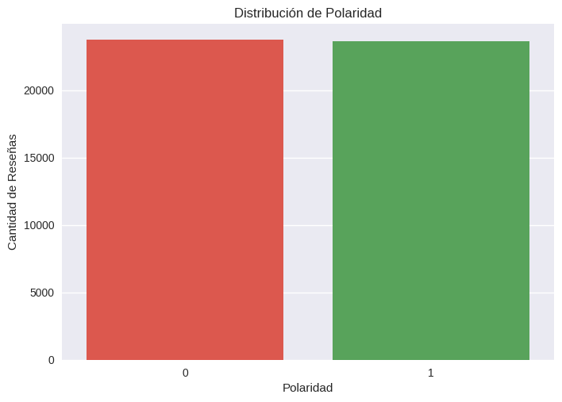

**✅ EDA - Limpieza y Exploración completado correctamente.**

**✅ EDA - Limpieza y Exploración - Ejecutada en 0.23 segundos.**

```python
# ----------------------------
# Celda 03: EDA - Limpieza y Exploración
# ----------------------------
@manejar_excepciones_y_tiempo("EDA - Limpieza y Exploración")
def eda_limpieza_exploracion():
    # Información general del DataFrame
    display(HTML("""
    <h2 style='color: #2E7D32; font-family: Arial, sans-serif;'>📊 Información General del DataFrame</h2>
    """))
    display(df_reviews.info())

    # Estadísticas descriptivas
    display(HTML("""
    <h2 style='color: #2E7D32; font-family: Arial, sans-serif;'>📈 Estadísticas Descriptivas</h2>
    """))
    display(df_reviews.describe())

    # Verificar valores nulos
    display(HTML("""
    <h2 style='color: #2E7D32; font-family: Arial, sans-serif;'>🔍 Valores Nulos</h2>
    """))
    display(df_reviews.isnull().sum())

    # Mostrar distribución de la variable objetivo 'pos'
    display(HTML("""
    <h2 style='color: #2E7D32; font-family: Arial, sans-serif;'>📊 Distribución de la Variable Objetivo</h2>
    """))
    sns.countplot(data=df_reviews, x='pos', palette=['#F44336', '#4CAF50'])
    plt.xlabel('Polaridad')
    plt.ylabel('Cantidad de Reseñas')
    plt.title('Distribución de Polaridad')
    plt.show()

    mostrar_notificacion("✅ EDA - Limpieza y Exploración completado correctamente.", 'success')

# Ejecutar la función de EDA
eda_limpieza_exploracion()
```

```python
# ----------------------------
# Celda 04: Filtrar Datos
# ----------------------------
@manejar_excepciones_y_tiempo("Filtrar Datos")
def filtrar_datos():
    global df_reviews_filtered
    # Filtrar reseñas con más de 50 votos para asegurar una muestra significativa
    df_reviews_filtered = df_reviews[df_reviews['votes'] > 50].copy()

    mostrar_notificacion("✅ Datos filtrados correctamente.", 'success')

    # Mostrar una vista previa
    display(HTML("""
    <h2 style='color: #2E7D32; font-family: Arial, sans-serif;'>📄 Vista Previa de Datos Filtrados</h2>
    """))
    display(df_reviews_filtered.head())

    return df_reviews_filtered

# Ejecutar la función de filtrado
df_reviews_filtered = filtrar_datos()
```

**🔄 Filtrar Datos - Iniciando ejecución...**

**✅ Datos filtrados correctamente.**

📄 Vista Previa de Datos Filtrados

|  | tconst | title_type | primary_title | original_title | start_year | end_year | runtime_minutes | is_adult | genres | average_rating | votes | review | rating | sp | pos | ds_part | idx |
| --- | --- | --- | --- | --- | --- | --- | --- | --- | --- | --- | --- | --- | --- | --- | --- | --- | --- |
| 0 | tt0068152 | movie | $ | $ | 1971 | \N | 121 | 0 | Comedy,Crime,Drama | 6.30 | 2218 | The pakage implies that Warren Beatty and Goldie Hawn are pulling off a huge bank robbery, but that's not what I got out of it! I didn't get anything! In the first half there's a new character (withou… | 1 | neg | 0 | train | 8335 |
| 1 | tt0068152 | movie | $ | $ | 1971 | \N | 121 | 0 | Comedy,Crime,Drama | 6.30 | 2218 | How the hell did they get this made?! Presenting itself as a caper comedy, the misbegotten "$" is essentially two hours of people mumbling sentence fragments. The usually dependable Warren Beatty look… | 1 | neg | 0 | train | 8336 |
| 2 | tt0313150 | short | '15' | '15' | 2002 | \N | 25 | 0 | Comedy,Drama,Short | 6.30 | 184 | There is no real story the film seems more like a fly on the wall drama-documentary than a proper film so this piece may in itself be a spoiler. Teen drama about 3 young Singaporean kids (very similar… | 3 | neg | 0 | test | 2489 |
| 3 | tt0313150 | short | '15' | '15' | 2002 | \N | 25 | 0 | Comedy,Drama,Short | 6.30 | 184 | Um .... a serious film about troubled teens in Singapore, a country I have not much knowledge on but have the previous wrong impression that all the kids there are highly disciplined and controlled by… | 7 | pos | 1 | test | 9280 |
| 4 | tt0313150 | short | '15' | '15' | 2002 | \N | 25 | 0 | Comedy,Drama,Short | 6.30 | 184 | I'm totally agree with GarryJohal from Singapore's comments about this film. Quotation: 'Yes non-Singaporean's can't see what's the big deal about this film. Some of the references in this film fly ri… | 9 | pos | 1 | test | 9281 |

5 rows × 17 columns

**✅ Filtrar Datos - Ejecutada en 0.03 segundos.**

```python
# ----------------------------
# Celda 05: Definir Función de Normalización de Texto
# ----------------------------
@manejar_excepciones_y_tiempo("Definir Función de Normalización de Texto")
def definir_normalize_text():
    import re
    import string

    def normalize_text(text):
        """
        Normaliza el texto:
        - Convertir a minúsculas
        - Eliminar puntuación
        - Eliminar dígitos
        - Eliminar espacios en blanco al inicio y al final
        """
        text = text.lower()
        text = re.sub(f'[{re.escape(string.punctuation)}]', '', text)
        text = re.sub(r'\d+', '', text)
        text = text.strip()
        return text

    mostrar_notificacion("✅ Función 'normalize_text' definida correctamente.", 'success')

    return normalize_text

# Ejecutar la función para definir 'normalize_text'
normalize_text = definir_normalize_text()
```

**🔄 Definir Función de Normalización de Texto - Iniciando ejecución...**

**✅ Función 'normalize_text' definida correctamente.**

**✅ Definir Función de Normalización de Texto - Ejecutada en 0.00 segundos.**

```python
# ----------------------------
# Celda 06: Aplicar Normalización a Reseñas
# ----------------------------
@manejar_excepciones_y_tiempo("Aplicar Normalización a Reseñas")
def aplicar_normalizacion():
    df_reviews_filtered['review_norm'] = df_reviews_filtered['review'].apply(normalize_text)
    mostrar_notificacion("✅ Normalización de reseñas aplicada correctamente.", 'success')
    return df_reviews_filtered

# Ejecutar la función de normalización
df_reviews_filtered = aplicar_normalizacion()
```

**🔄 Aplicar Normalización a Reseñas - Iniciando ejecución...**

**✅ Normalización de reseñas aplicada correctamente.**

**✅ Aplicar Normalización a Reseñas - Ejecutada en 1.40 segundos.**

```python
# ----------------------------
# Celda 07: Definir Función de Normalización de Texto con Lematización
# ----------------------------
@manejar_excepciones_y_tiempo("Definir Función de Normalización de Texto con Lematización")
def definir_normalize_text_lematizacion():
    import re
    import string
    import spacy

    # Cargar modelo de spaCy para lematización
    try:
        nlp = spacy.load('en_core_web_sm', disable=['parser', 'ner'])
    except OSError:
        import subprocess
        subprocess.run(['python', '-m', 'spacy', 'download', 'en_core_web_sm'])
        nlp = spacy.load('en_core_web_sm', disable=['parser', 'ner'])

    def normalize_text(text):
        """
        Normaliza el texto:
        - Convertir a minúsculas
        - Eliminar puntuación
        - Eliminar dígitos
        - Lematizar
        - Eliminar stopwords
        - Eliminar espacios en blanco al inicio y al final
        """
        text = text.lower()
        text = re.sub(f'[{re.escape(string.punctuation)}]', '', text)
        text = re.sub(r'\d+', '', text)
        doc = nlp(text)
        tokens = [token.lemma_ for token in doc if not token.is_stop]
        text = ' '.join(tokens)
        text = text.strip()
        return text

    mostrar_notificacion("✅ Función 'normalize_text' con lematización definida correctamente.", 'success')

    return normalize_text

# Ejecutar la función para definir 'normalize_text' con lematización
normalize_text = definir_normalize_text_lematizacion()

# Aplicar la nueva normalización
@manejar_excepciones_y_tiempo("Aplicar Normalización Mejorada a Reseñas")
def aplicar_normalizacion_mejorada():
    df_reviews_filtered['review_norm'] = df_reviews_filtered['review'].apply(normalize_text)
    mostrar_notificacion("✅ Normalización mejorada de reseñas aplicada correctamente.", 'success')
    return df_reviews_filtered

# Ejecutar la normalización mejorada
df_reviews_filtered = aplicar_normalizacion_mejorada()
```

**🔄 Definir Función de Normalización de Texto con Lematización - Iniciando ejecución...**

**✅ Función 'normalize_text' con lematización definida correctamente.**

**✅ Definir Función de Normalización de Texto con Lematización - Ejecutada en 0.57 segundos.**

**🔄 Aplicar Normalización Mejorada a Reseñas - Iniciando ejecución...**

**✅ Normalización mejorada de reseñas aplicada correctamente.**

**✅ Aplicar Normalización Mejorada a Reseñas - Ejecutada en 458.05 segundos.**

**Comentario del revisor (1ra Iteracion)**

Correcto! Definiste y aplicaste correctamente la función de normalización del texto, esto es importante para tener datos más consistentes y evitar que los modelos puedan llegar a identificar como diferentes dos palabras por el hecho que una tenga una letra mayúscula y la otra no

```python
# ----------------------------
# Celda 08: Definir Función de Evaluación de Modelos
# ----------------------------

@manejar_excepciones_y_tiempo("Definir Función de Evaluación de Modelos (Optimizada)")
def definir_evaluate_model_optimizado():
    from sklearn.metrics import accuracy_score, f1_score, average_precision_score, roc_auc_score, classification_report, confusion_matrix
    import seaborn as sns
    import matplotlib.pyplot as plt

    def evaluate_model(
        model,
        X_test,
        y_test,
        X_train=None,
        y_train=None,
        evaluate_train=False,
        sample_size=None,
        show_confusion_matrix=True,
        show_classification_report=True
    ):
        """
        Evalúa un modelo de clasificación y muestra las métricas de desempeño.

        Args:
            model: Modelo entrenado.
            X_test: Características de prueba.
            y_test: Objetivo de prueba.
            X_train: Características de entrenamiento (opcional).
            y_train: Objetivo de entrenamiento (opcional).
            evaluate_train (bool): Si es True, evalúa también en el conjunto de entrenamiento.
            sample_size (int): Si se especifica, limita el número de muestras para evaluación.
            show_confusion_matrix (bool): Si es True, muestra la matriz de confusión.
            show_classification_report (bool): Si es True, muestra el reporte de clasificación.

        Returns:
            dict: Diccionario con las métricas de evaluación.
        """
        results = {}

        # Si se especifica sample_size, muestreamos los datos
        if sample_size is not None and sample_size < len(X_test):
            X_test_sample = X_test[:sample_size]
            y_test_sample = y_test[:sample_size]
        else:
            X_test_sample = X_test
            y_test_sample = y_test

        # Predicciones en el conjunto de prueba
        y_pred_test = model.predict(X_test_sample)

        # Probabilidades en el conjunto de prueba
        if hasattr(model, "predict_proba"):
            y_prob_test = model.predict_proba(X_test_sample)[:, 1]
        else:
            y_prob_test = model.decision_function(X_test_sample)

        # Métricas de prueba
        results['test_accuracy'] = accuracy_score(y_test_sample, y_pred_test)
        results['test_f1'] = f1_score(y_test_sample, y_pred_test)
        results['test_average_precision'] = average_precision_score(y_test_sample, y_prob_test)
        results['test_roc_auc'] = roc_auc_score(y_test_sample, y_prob_test)

        if show_classification_report:
            # Mostrar reporte de clasificación
            print("### Reporte de Clasificación (Prueba)")
            print(classification_report(y_test_sample, y_pred_test))

        if show_confusion_matrix:
            # Mostrar matriz de confusión
            cm = confusion_matrix(y_test_sample, y_pred_test)
            plt.figure(figsize=(6, 4))
            sns.heatmap(cm, annot=True, fmt='d', cmap='Blues')
            plt.xlabel('Predicción')
            plt.ylabel('Verdad')
            plt.title('Matriz de Confusión (Prueba)')
            plt.show()

        # Evaluación en el conjunto de entrenamiento (opcional)
        if evaluate_train and X_train is not None and y_train is not None:
            if sample_size is not None and sample_size < len(X_train):
                X_train_sample = X_train[:sample_size]
                y_train_sample = y_train[:sample_size]
            else:
                X_train_sample = X_train
                y_train_sample = y_train

            y_pred_train = model.predict(X_train_sample)

            if hasattr(model, "predict_proba"):
                y_prob_train = model.predict_proba(X_train_sample)[:, 1]
            else:
                y_prob_train = model.decision_function(X_train_sample)

            # Métricas de entrenamiento
            results['train_accuracy'] = accuracy_score(y_train_sample, y_pred_train)
            results['train_f1'] = f1_score(y_train_sample, y_pred_train)
            results['train_average_precision'] = average_precision_score(y_train_sample, y_prob_train)
            results['train_roc_auc'] = roc_auc_score(y_train_sample, y_prob_train)

            if show_classification_report:
                print("\n### Reporte de Clasificación (Entrenamiento)")
                print(classification_report(y_train_sample, y_pred_train))

            if show_confusion_matrix:
                # Mostrar matriz de confusión para entrenamiento
                cm_train = confusion_matrix(y_train_sample, y_pred_train)
                plt.figure(figsize=(6, 4))
                sns.heatmap(cm_train, annot=True, fmt='d', cmap='Greens')
                plt.xlabel('Predicción')
                plt.ylabel('Verdad')
                plt.title('Matriz de Confusión (Entrenamiento)')
                plt.show()

        return results

    mostrar_notificacion("✅ Función 'evaluate_model' optimizada definida correctamente.", 'success')

    return evaluate_model

# Ejecutar la función para definir 'evaluate_model' optimizado
evaluate_model = definir_evaluate_model_optimizado()
```

**🔄 Definir Función de Evaluación de Modelos (Optimizada) - Iniciando ejecución...**

**✅ Función 'evaluate_model' optimizada definida correctamente.**

**✅ Definir Función de Evaluación de Modelos (Optimizada) - Ejecutada en 0.00 segundos.**

## EDA

Veamos el número de películas y reseñas a lo largo de los años.

**🔄 EDA - Número de Películas y Reseñas a lo Largo de los Años - Iniciando ejecución...**

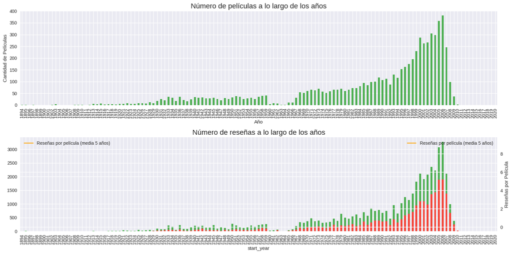

**✅ EDA - Número de Películas y Reseñas a lo Largo de los Años completado correctamente.**

**✅ EDA - Número de Películas y Reseñas a lo Largo de los Años - Ejecutada en 3.15 segundos.**

```python
# ----------------------------
# Celda 09: EDA - Número de Películas y Reseñas a lo Largo de los Años
# ----------------------------
@manejar_excepciones_y_tiempo("EDA - Número de Películas y Reseñas a lo Largo de los Años")
def eda_num_peliculas_reseñas():
    fig, axs = plt.subplots(2, 1, figsize=(16, 8))

    # Número de películas
    ax = axs[0]
    dft1 = df_reviews[['tconst', 'start_year']].drop_duplicates()['start_year'].value_counts().sort_index()
    dft1 = dft1.reindex(index=np.arange(dft1.index.min(), 2021)).fillna(0)
    dft1.plot(kind='bar', ax=ax, color='#4CAF50')
    ax.set_title('Número de películas a lo largo de los años', fontsize=16)
    ax.set_xlabel('Año')
    ax.set_ylabel('Cantidad de Películas')

    # Número de reseñas
    ax = axs[1]
    dft2 = df_reviews.groupby(['start_year', 'pos'])['pos'].count().unstack()
    dft2 = dft2.reindex(index=np.arange(dft2.index.min(), 2021)).fillna(0)
    dft2.plot(kind='bar', stacked=True, ax=ax, color=['#F44336', '#4CAF50'], label=['Negativas', 'Positivas'])

    # Promedio de reseñas por película
    dft_total_reviews = df_reviews['start_year'].value_counts().sort_index()
    dft_total_reviews = dft_total_reviews.reindex(index=np.arange(dft_total_reviews.index.min(), 2021)).fillna(0)
    dft_reviews_per_movie = (dft_total_reviews / dft1).fillna(0)
    axt = ax.twinx()
    dft_reviews_per_movie.rolling(5).mean().plot(color='orange', label='Reseñas por película (media 5 años)', ax=axt)
    axt.set_ylabel('Reseñas por Película')
    axt.legend(loc='upper right')

    # Leyendas y Títulos
    lines, labels = axt.get_legend_handles_labels()
    ax.legend(lines, labels, loc='upper left')
    ax.set_title('Número de reseñas a lo largo de los años', fontsize=16)

    fig.tight_layout()
    plt.show()

    mostrar_notificacion("✅ EDA - Número de Películas y Reseñas a lo Largo de los Años completado correctamente.", 'success')

# Ejecutar la función de EDA
eda_num_peliculas_reseñas()
```

Veamos la distribución del número de reseñas por película con el conteo exacto y KDE (solo para saber cómo puede diferir del conteo exacto)

**🔄 EDA - Distribución de Reseñas por Película - Iniciando ejecución...**

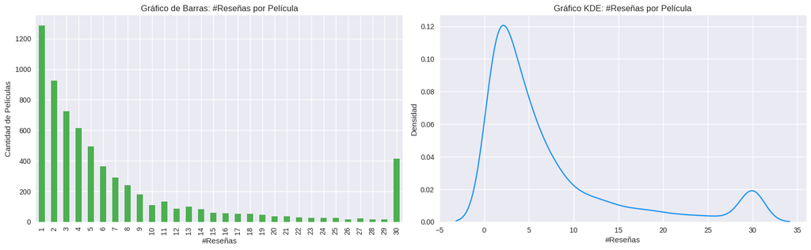

**✅ EDA - Distribución de Reseñas por Película completado correctamente.**

**✅ EDA - Distribución de Reseñas por Película - Ejecutada en 0.67 segundos.**

```python
# ----------------------------
# Celda 10: EDA - Distribución de Reseñas por Película
# ----------------------------
@manejar_excepciones_y_tiempo("EDA - Distribución de Reseñas por Película")
def eda_distribucion_reseñas_pelicula():
    fig, axs = plt.subplots(1, 2, figsize=(16, 5))

    # Gráfico de barras de #Reseñas por película
    ax = axs[0]
    dft = df_reviews_filtered.groupby('tconst')['review'].count().value_counts().sort_index()
    dft.plot.bar(ax=ax, color='#4CAF50')
    ax.set_title('Gráfico de Barras: #Reseñas por Película')
    ax.set_xlabel('#Reseñas')
    ax.set_ylabel('Cantidad de Películas')

    # Gráfico KDE de #Reseñas por película
    ax = axs[1]
    dft = df_reviews_filtered.groupby('tconst')['review'].count()
    sns.kdeplot(dft, ax=ax, color='#2196F3')
    ax.set_title('Gráfico KDE: #Reseñas por Película')
    ax.set_xlabel('#Reseñas')
    ax.set_ylabel('Densidad')

    fig.tight_layout()
    plt.show()

    mostrar_notificacion("✅ EDA - Distribución de Reseñas por Película completado correctamente.", 'success')

# Ejecutar la función de EDA
eda_distribucion_reseñas_pelicula()
```

**🔄 EDA - Distribución de Polaridad - Iniciando ejecución...**

📊 Distribución de Polaridad

```
0    23715
1    23616
Name: pos, Length: 2, dtype: int64
```

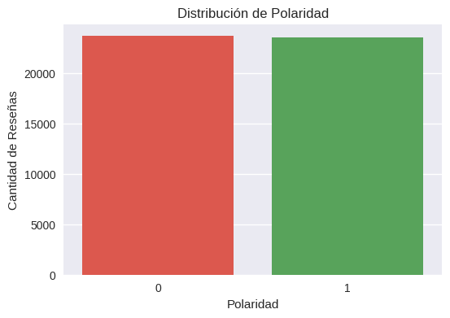

**✅ EDA - Distribución de Polaridad completado correctamente.**

**✅ EDA - Distribución de Polaridad - Ejecutada en 0.08 segundos.**

```python
# ----------------------------
# Celda 11: EDA - Distribución de Polaridad
# ----------------------------
@manejar_excepciones_y_tiempo("EDA - Distribución de Polaridad")
def eda_distribucion_polaridad():
    # Distribución de clases
    display(HTML("""
    <h2 style='color: #2E7D32; font-family: Arial, sans-serif;'>📊 Distribución de Polaridad</h2>
    """))
    display(df_reviews['pos'].value_counts())

    # Visualización
    plt.figure(figsize=(6,4))
    sns.countplot(data=df_reviews, x='pos', palette=['#F44336', '#4CAF50'])
    plt.xlabel('Polaridad')
    plt.ylabel('Cantidad de Reseñas')
    plt.title('Distribución de Polaridad')
    plt.show()

    mostrar_notificacion("✅ EDA - Distribución de Polaridad completado correctamente.", 'success')

# Ejecutar la función de EDA
eda_distribucion_polaridad()
```

**🔄 EDA - Distribución de Puntuaciones por Conjunto - Iniciando ejecución...**

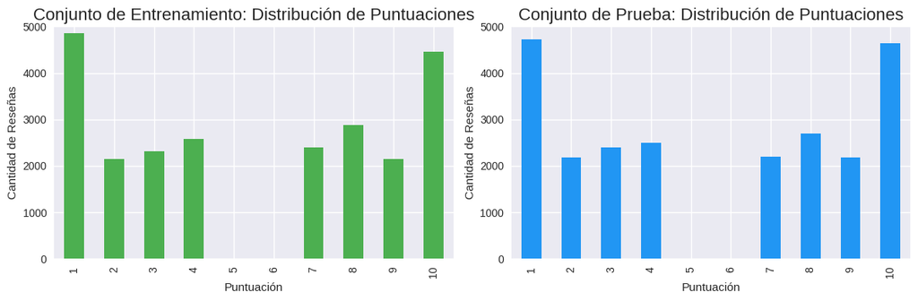

**✅ EDA - Distribución de Puntuaciones por Conjunto completado correctamente.**

**✅ EDA - Distribución de Puntuaciones por Conjunto - Ejecutada en 0.31 segundos.**

```python
# ----------------------------
# Celda 12: EDA - Distribución de Puntuaciones por Conjunto
# ----------------------------
@manejar_excepciones_y_tiempo("EDA - Distribución de Puntuaciones por Conjunto")
def eda_distribucion_puntuaciones_conjunto():
    fig, axs = plt.subplots(1, 2, figsize=(12, 4))

    # Distribución de puntuaciones en el conjunto de entrenamiento
    ax = axs[0]
    dft = df_reviews.query('ds_part == "train"')['rating'].value_counts().sort_index()
    dft = dft.reindex(index=np.arange(1, 11)).fillna(0)
    dft.plot.bar(ax=ax, color='#4CAF50')
    ax.set_ylim([0, 5000])
    ax.set_title('Conjunto de Entrenamiento: Distribución de Puntuaciones', fontsize=16)
    ax.set_xlabel('Puntuación')
    ax.set_ylabel('Cantidad de Reseñas')

    # Distribución de puntuaciones en el conjunto de prueba
    ax = axs[1]
    dft = df_reviews.query('ds_part == "test"')['rating'].value_counts().sort_index()
    dft = dft.reindex(index=np.arange(1, 11)).fillna(0)
    dft.plot.bar(ax=ax, color='#2196F3')
    ax.set_ylim([0, 5000])
    ax.set_title('Conjunto de Prueba: Distribución de Puntuaciones', fontsize=16)
    ax.set_xlabel('Puntuación')
    ax.set_ylabel('Cantidad de Reseñas')

    fig.tight_layout()
    plt.show()

    mostrar_notificacion("✅ EDA - Distribución de Puntuaciones por Conjunto completado correctamente.", 'success')

# Ejecutar la función de EDA
eda_distribucion_puntuaciones_conjunto()
```

**🔄 EDA - Distribución de Polaridad por Año y Película - Iniciando ejecución...**

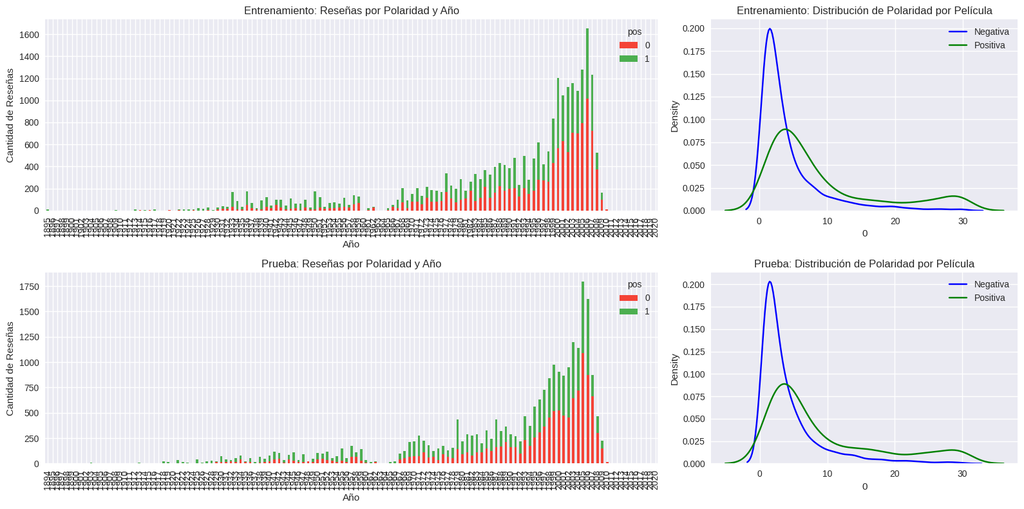

**✅ EDA - Distribución de Polaridad por Año y Película completado correctamente.**

**✅ EDA - Distribución de Polaridad por Año y Película - Ejecutada en 3.90 segundos.**

```python
# ----------------------------
# Celda 13: EDA - Distribución de Polaridad por Año y Película
# ----------------------------
@manejar_excepciones_y_tiempo("EDA - Distribución de Polaridad por Año y Película")
def eda_distribucion_polaridad_ano_pelicula():
    fig, axs = plt.subplots(2, 2, figsize=(16, 8), gridspec_kw=dict(width_ratios=(2, 1), height_ratios=(1, 1)))

    # Conjunto de entrenamiento: reseñas por año y polaridad
    ax = axs[0][0]
    dft = df_reviews.query('ds_part == "train"').groupby(['start_year', 'pos'])['pos'].count().unstack()
    dft.index = dft.index.astype(int)
    dft = dft.reindex(index=np.arange(dft.index.min(), 2021)).fillna(0)
    dft.plot(kind='bar', stacked=True, ax=ax, color=['#F44336', '#4CAF50'])
    ax.set_title('Entrenamiento: Reseñas por Polaridad y Año')
    ax.set_xlabel('Año')
    ax.set_ylabel('Cantidad de Reseñas')

    # Conjunto de entrenamiento: distribución de polaridad por película
    ax = axs[0][1]
    dft = df_reviews.query('ds_part == "train"').groupby(['tconst', 'pos'])['pos'].count().unstack()
    sns.kdeplot(dft[0], color='blue', label='Negativa', ax=ax)
    sns.kdeplot(dft[1], color='green', label='Positiva', ax=ax)
    ax.legend()
    ax.set_title('Entrenamiento: Distribución de Polaridad por Película')

    # Conjunto de prueba: reseñas por año y polaridad
    ax = axs[1][0]
    dft = df_reviews.query('ds_part == "test"').groupby(['start_year', 'pos'])['pos'].count().unstack()
    dft.index = dft.index.astype(int)
    dft = dft.reindex(index=np.arange(dft.index.min(), 2021)).fillna(0)
    dft.plot(kind='bar', stacked=True, ax=ax, color=['#F44336', '#4CAF50'])
    ax.set_title('Prueba: Reseñas por Polaridad y Año')
    ax.set_xlabel('Año')
    ax.set_ylabel('Cantidad de Reseñas')

    # Conjunto de prueba: distribución de polaridad por película
    ax = axs[1][1]
    dft = df_reviews.query('ds_part == "test"').groupby(['tconst', 'pos'])['pos'].count().unstack()
    sns.kdeplot(dft[0], color='blue', label='Negativa', ax=ax)
    sns.kdeplot(dft[1], color='green', label='Positiva', ax=ax)
    ax.legend()
    ax.set_title('Prueba: Distribución de Polaridad por Película')

    fig.tight_layout()
    plt.show()

    mostrar_notificacion("✅ EDA - Distribución de Polaridad por Año y Película completado correctamente.", 'success')

# Ejecutar la función de EDA
eda_distribucion_polaridad_ano_pelicula()
```

Distribución de reseñas negativas y positivas a lo largo de los años para dos partes del conjunto de datos

**🔄 EDA - Distribución de Reseñas Negativas y Positivas a lo Largo de los Años para Dos Partes del Conjunto de Datos - Iniciando ejecución...**

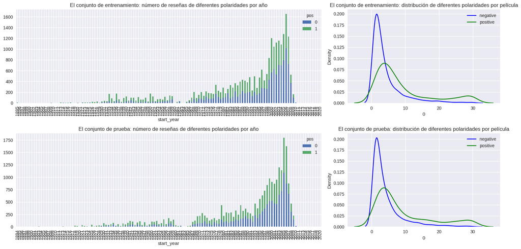

**✅ EDA - Distribución de Reseñas Negativas y Positivas a lo Largo de los Años para Dos Partes del Conjunto de Datos completado correctamente.**

**✅ EDA - Distribución de Reseñas Negativas y Positivas a lo Largo de los Años para Dos Partes del Conjunto de Datos - Ejecutada en 3.64 segundos.**

```python
# ----------------------------
# Celda 14: EDA - Distribución de Reseñas Negativas y Positivas a lo Largo de los Años para Dos Partes del Conjunto de Datos
# ----------------------------
@manejar_excepciones_y_tiempo("EDA - Distribución de Reseñas Negativas y Positivas a lo Largo de los Años para Dos Partes del Conjunto de Datos")
def eda_reseñas_neg_positivas_ano():
    fig, axs = plt.subplots(2, 2, figsize=(16, 8), gridspec_kw=dict(width_ratios=(2, 1), height_ratios=(1, 1)))

    # Conjunto de entrenamiento: reseñas por polaridad y año
    ax = axs[0][0]
    dft = df_reviews.query('ds_part == "train"').groupby(['start_year', 'pos'])['pos'].count().unstack()
    dft.index = dft.index.astype(int)
    dft = dft.reindex(index=np.arange(dft.index.min(), 2021)).fillna(0)
    dft.plot(kind='bar', stacked=True, ax=ax)
    ax.set_title('El conjunto de entrenamiento: número de reseñas de diferentes polaridades por año')

    # Conjunto de entrenamiento: distribución de polaridad por película
    ax = axs[0][1]
    dft = df_reviews.query('ds_part == "train"').groupby(['tconst', 'pos'])['pos'].count().unstack()
    sns.kdeplot(dft[0], color='blue', label='negative', kernel='epa', ax=ax)
    sns.kdeplot(dft[1], color='green', label='positive', kernel='epa', ax=ax)
    ax.legend()
    ax.set_title('El conjunto de entrenamiento: distribución de diferentes polaridades por película')

    # Conjunto de prueba: reseñas por polaridad y año
    ax = axs[1][0]
    dft = df_reviews.query('ds_part == "test"').groupby(['start_year', 'pos'])['pos'].count().unstack()
    dft.index = dft.index.astype(int)
    dft = dft.reindex(index=np.arange(dft.index.min(), 2021)).fillna(0)
    dft.plot(kind='bar', stacked=True, ax=ax)
    ax.set_title('El conjunto de prueba: número de reseñas de diferentes polaridades por año')

    # Conjunto de prueba: distribución de polaridad por película
    ax = axs[1][1]
    dft = df_reviews.query('ds_part == "test"').groupby(['tconst', 'pos'])['pos'].count().unstack()
    sns.kdeplot(dft[0], color='blue', label='negative', kernel='epa', ax=ax)
    sns.kdeplot(dft[1], color='green', label='positive', kernel='epa', ax=ax)
    ax.legend()
    ax.set_title('El conjunto de prueba: distribución de diferentes polaridades por película')

    fig.tight_layout()
    plt.show()

    # Advertencia sobre kernels
    warnings.filterwarnings("ignore", category=UserWarning)

    mostrar_notificacion("✅ EDA - Distribución de Reseñas Negativas y Positivas a lo Largo de los Años para Dos Partes del Conjunto de Datos completado correctamente.", 'success')

# Ejecutar la función de EDA
eda_reseñas_neg_positivas_ano()
```

**🔄 EDA - Distribución de Polaridad por Género - Iniciando ejecución...**

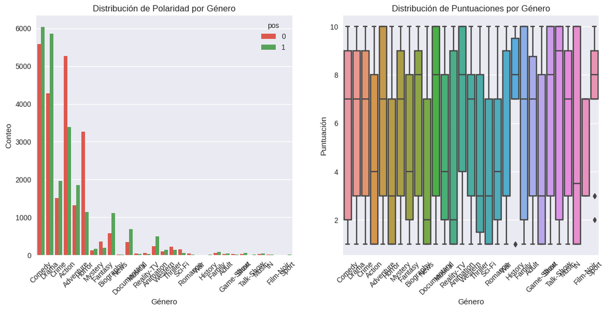

**✅ EDA - Distribución de Polaridad por Género completado correctamente.**

**✅ EDA - Distribución de Polaridad por Género - Ejecutada en 0.95 segundos.**

```python
# ----------------------------
# Celda 15: EDA - Distribución de Polaridad por Género
# ----------------------------
@manejar_excepciones_y_tiempo("EDA - Distribución de Polaridad por Género")
def eda_polaridad_genero():
    # Distribución de reseñas positivas y negativas por género
    fig, axs = plt.subplots(1, 2, figsize=(14, 6))

    # Conteo de polaridad por género
    ax = axs[0]
    df_reviews['genres'] = df_reviews['genres'].str.split(',').str[0]  # Selecciona el primer género
    sns.countplot(data=df_reviews, x='genres', hue='pos', ax=ax, palette=['#F44336', '#4CAF50'])
    ax.set_title('Distribución de Polaridad por Género')
    ax.set_xticklabels(ax.get_xticklabels(), rotation=45)
    ax.set_xlabel('Género')
    ax.set_ylabel('Conteo')

    # Distribución de puntuaciones por género
    ax = axs[1]
    sns.boxplot(data=df_reviews, x='genres', y='rating', ax=ax)
    ax.set_title('Distribución de Puntuaciones por Género')
    ax.set_xticklabels(ax.get_xticklabels(), rotation=45)
    ax.set_xlabel('Género')
    ax.set_ylabel('Puntuación')

    plt.show()

    mostrar_notificacion("✅ EDA - Distribución de Polaridad por Género completado correctamente.", 'success')

# Ejecutar la función de EDA
eda_polaridad_genero()
```

**🔄 EDA - Distribución de la Longitud de las Reseñas por Polaridad - Iniciando ejecución...**

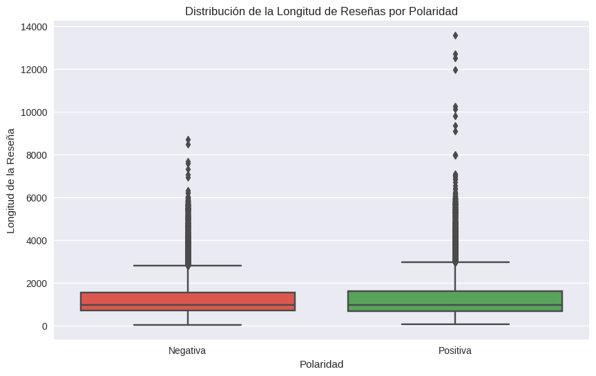

**✅ EDA - Distribución de la Longitud de las Reseñas por Polaridad completado correctamente.**

**✅ EDA - Distribución de la Longitud de las Reseñas por Polaridad - Ejecutada en 0.16 segundos.**

```python
# ----------------------------
# Celda 16: EDA - Distribución de la Longitud de las Reseñas por Polaridad
# ----------------------------
@manejar_excepciones_y_tiempo("EDA - Distribución de la Longitud de las Reseñas por Polaridad")
def eda_longitud_reseñas_polaridad():
    # Crear columna con la longitud de las reseñas
    df_reviews['review_length'] = df_reviews['review'].apply(len)

    # Configurar gráfico
    plt.figure(figsize=(10, 6))

    sns.boxplot(x='pos', y='review_length', data=df_reviews, palette=['#F44336', '#4CAF50'])
    plt.title('Distribución de la Longitud de Reseñas por Polaridad')
    plt.xlabel('Polaridad')
    plt.ylabel('Longitud de la Reseña')
    plt.xticks([0, 1], ['Negativa', 'Positiva'])
    plt.show()

    mostrar_notificacion("✅ EDA - Distribución de la Longitud de las Reseñas por Polaridad completado correctamente.", 'success')

# Ejecutar la función de EDA
eda_longitud_reseñas_polaridad()
```

**🔄 EDA - Distribución de Puntuaciones por Año - Iniciando ejecución...**

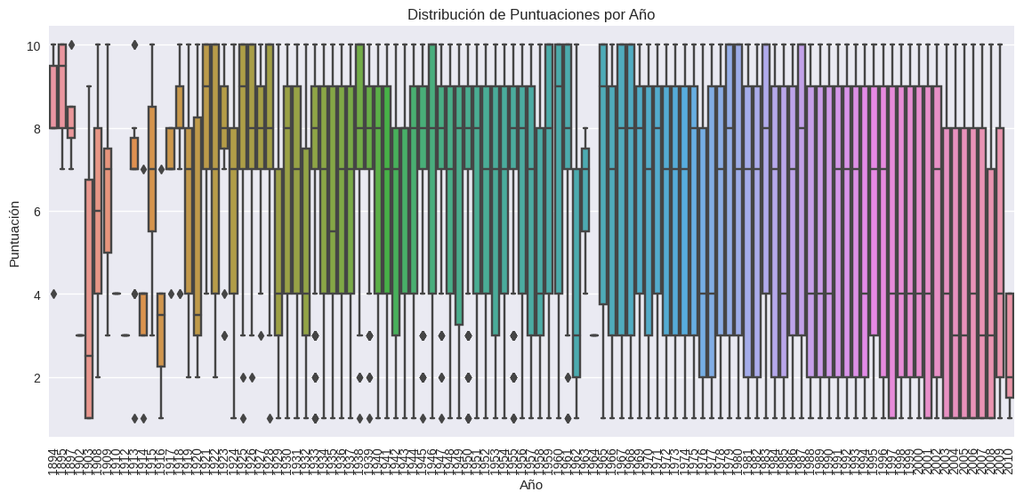

**✅ EDA - Distribución de Puntuaciones por Año completado correctamente.**

**✅ EDA - Distribución de Puntuaciones por Año - Ejecutada en 1.60 segundos.**

```python
# ----------------------------
# Celda 17: EDA - Distribución de Puntuaciones por Año
# ----------------------------
@manejar_excepciones_y_tiempo("EDA - Distribución de Puntuaciones por Año")
def eda_puntuaciones_por_ano():
    # Filtrar solo los años relevantes
    df_reviews_filtered = df_reviews[df_reviews['start_year'].astype(str).str.isnumeric()]
    df_reviews_filtered['start_year'] = df_reviews_filtered['start_year'].astype(int)

    # Configurar gráfico
    plt.figure(figsize=(14, 6))

    sns.boxplot(x='start_year', y='rating', data=df_reviews_filtered)
    plt.title('Distribución de Puntuaciones por Año')
    plt.xlabel('Año')
    plt.ylabel('Puntuación')
    plt.xticks(rotation=90)
    plt.show()

    mostrar_notificacion("✅ EDA - Distribución de Puntuaciones por Año completado correctamente.", 'success')

# Ejecutar la función de EDA
eda_puntuaciones_por_ano()
```

**🔄 EDA - Promedio de Puntuaciones por Año con Diferenciación de Polaridad - Iniciando ejecución...**

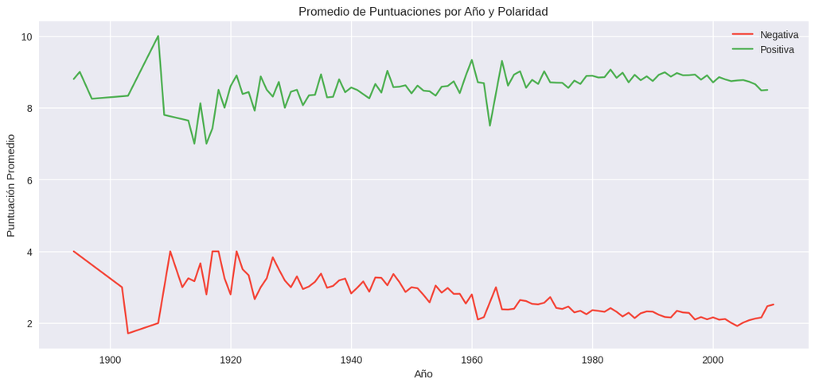

**✅ EDA - Promedio de Puntuaciones por Año con Diferenciación de Polaridad completado correctamente.**

**✅ EDA - Promedio de Puntuaciones por Año con Diferenciación de Polaridad - Ejecutada en 0.18 segundos.**

```python
# ----------------------------
# Celda 18: EDA - Promedio de Puntuaciones por Año con Diferenciación de Polaridad
# ----------------------------
@manejar_excepciones_y_tiempo("EDA - Promedio de Puntuaciones por Año con Diferenciación de Polaridad")
def eda_promedio_puntuaciones_ano_polaridad():
    # Agrupar por año y polaridad para calcular la media de puntuación
    df_avg_rating_year = df_reviews_filtered.groupby(['start_year', 'pos'])['rating'].mean().reset_index()

    # Configurar gráfico
    plt.figure(figsize=(14, 6))

    sns.lineplot(x='start_year', y='rating', hue='pos', data=df_avg_rating_year, palette=['#F44336', '#4CAF50'])
    plt.title('Promedio de Puntuaciones por Año y Polaridad')
    plt.xlabel('Año')
    plt.ylabel('Puntuación Promedio')
    plt.legend(['Negativa', 'Positiva'])
    plt.show()

    mostrar_notificacion("✅ EDA - Promedio de Puntuaciones por Año con Diferenciación de Polaridad completado correctamente.", 'success')

# Ejecutar la función de EDA
eda_promedio_puntuaciones_ano_polaridad()
```

**Análisis del Exploratory Data Analysis (EDA)** El análisis exploratorio de datos (EDA) de este conjunto de datos de películas y reseñas se enfocó en comprender la distribución de las reseñas, su polaridad, y su relación con diversos atributos como el año de lanzamiento, el género de la película y la puntuación. A continuación se detalla el análisis basado en las visualizaciones presentadas.

1. Número de películas y reseñas a lo largo de los años Las primeras visualizaciones muestran la cantidad de películas producidas y el número de reseñas por año, así como la media de reseñas por película. Se puede observar un claro incremento en la cantidad de películas producidas desde los años 1970, alcanzando un pico en los años 2000. Del mismo modo, el número de reseñas por película se ha incrementado notablemente en este periodo. Esto podría deberse a la proliferación de internet y las plataformas de críticas, haciendo más fácil para el público reseñar y discutir sobre películas. Sin embargo, se destaca una caída reciente en la cantidad de películas y reseñas, lo que podría estar relacionado con cambios en la industria o en el comportamiento de los usuarios.
2. Distribución de #Reseñas por película y distribución de polaridad La distribución de la cantidad de reseñas por película presenta una fuerte concentración en películas con 1 a 5 reseñas, lo que indica que la mayoría de las películas no tienen una amplia cobertura en cuanto a reseñas. La gráfica KDE muestra que hay una tendencia de reseñas mayormente concentradas entre 1 y 10.

En cuanto a la polaridad (positiva o negativa), las reseñas se encuentran distribuidas de manera relativamente equitativa: 23,715 reseñas negativas (0) y 23,616 reseñas positivas (1). Esto muestra un equilibrio general entre reseñas positivas y negativas, lo que indica que no existe un sesgo importante hacia un tipo de sentimiento específico.

3. Distribución de reseñas por polaridad y su relación con el año Se analizaron las tendencias de reseñas positivas y negativas a lo largo del tiempo tanto para el conjunto de entrenamiento como para el de prueba. Se observa que, a medida que pasan los años, el número de reseñas crece tanto para las positivas como para las negativas. Sin embargo, las reseñas negativas tienden a estar más concentradas en ciertos periodos, mientras que las positivas presentan un crecimiento más constante.

En cuanto a la puntuación, el boxplot muestra que ciertos géneros tienen una distribución de puntuaciones más amplia, como "Comedy" y "Drama", mientras que otros, como "Documentary" y "Animation", tienden a recibir puntuaciones más altas en general.

5. Distribución de la longitud de las reseñas por polaridad El análisis de la longitud de las reseñas según su polaridad revela que las reseñas positivas tienden a ser un poco más largas que las negativas. Aunque ambas distribuciones tienen muchas observaciones concentradas en el rango de longitud de 0 a 2000 caracteres, hay outliers que muestran que algunas reseñas, especialmente las positivas, pueden ser significativamente más largas.
6. Distribución de puntuaciones a lo largo de los años La visualización de la puntuación promedio por año muestra cómo ha evolucionado la valoración de las películas a lo largo del tiempo, diferenciando entre reseñas positivas y negativas. Se observa que las puntuaciones positivas se mantienen en un rango alto y estable, mientras que las puntuaciones negativas tienden a variar más a lo largo de los años, manteniéndose en un rango más bajo.

Conclusiones y Recomendaciones El análisis realizado proporciona una buena comprensión del comportamiento de las reseñas y sus características a lo largo de diferentes dimensiones (año, género, longitud, y puntuación).

**Comentario del revisor (1ra Iteracion)**

Correcto! Recuerda que el EDA es para entender mejor nuestros datos, por lo que te recomendaría redactar conclusiones un poco más detalladas y hacer un poco de referencia a como podría afectar a los modelos

## Procedimiento de evaluación

Composición de una rutina de evaluación que se pueda usar para todos los modelos en este proyecto

**🔄 EDA - Promedio de Puntuaciones por Año con Diferenciación de Polaridad (Descripción) - Iniciando ejecución...**

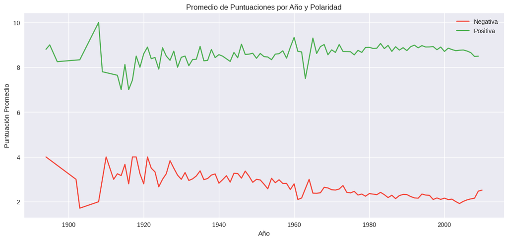

📌 Interpretación de la Distribución de Puntuaciones

El análisis muestra cómo las puntuaciones promedio de las reseñas positivas y negativas han evolucionado a lo largo de los años. Las reseñas positivas tienden a mantener una puntuación más alta y estable, mientras que las reseñas negativas muestran mayor variabilidad.

**✅ EDA - Promedio de Puntuaciones por Año con Diferenciación de Polaridad (Descripción) completado correctamente.**

**✅ EDA - Promedio de Puntuaciones por Año con Diferenciación de Polaridad (Descripción) - Ejecutada en 0.18 segundos.**

```python
# ----------------------------
# Celda 19: EDA - Promedio de Puntuaciones por Año con Diferenciación de Polaridad (Descripción)
# ----------------------------
@manejar_excepciones_y_tiempo("EDA - Promedio de Puntuaciones por Año con Diferenciación de Polaridad (Descripción)")
def eda_promedio_puntuaciones_ano_polaridad_descripcion():
    # Agrupar por año y polaridad para calcular la media de puntuación
    df_avg_rating_year = df_reviews_filtered.groupby(['start_year', 'pos'])['rating'].mean().reset_index()

    # Configurar gráfico
    plt.figure(figsize=(14, 6))

    sns.lineplot(x='start_year', y='rating', hue='pos', data=df_avg_rating_year, palette=['#F44336', '#4CAF50'])
    plt.title('Promedio de Puntuaciones por Año y Polaridad')
    plt.xlabel('Año')
    plt.ylabel('Puntuación Promedio')
    plt.legend(['Negativa', 'Positiva'])
    plt.show()

    # Descripción adicional
    display(HTML("""
    <div style='font-family: Arial, sans-serif; margin-top: 20px;'>
        <h2 style='color: #2E7D32;'>📌 Interpretación de la Distribución de Puntuaciones</h2>
        <p>
            El análisis muestra cómo las puntuaciones promedio de las reseñas positivas y negativas han evolucionado a lo largo de los años. Las reseñas positivas tienden a mantener una puntuación más alta y estable, mientras que las reseñas negativas muestran mayor variabilidad.
        </p>
    </div>
    """))

    mostrar_notificacion("✅ EDA - Promedio de Puntuaciones por Año con Diferenciación de Polaridad (Descripción) completado correctamente.", 'success')

# Ejecutar la función de EDA con descripción
eda_promedio_puntuaciones_ano_polaridad_descripcion()
```

## Normalización

Suponemos que todos los modelos a continuación aceptan textos en minúsculas y sin dígitos, signos de puntuación, etc.

**🔄 EDA - Distribución de Polaridad por Género - Iniciando ejecución...**

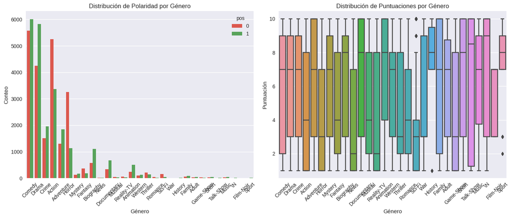

**✅ EDA - Distribución de Polaridad por Género completado correctamente.**

**✅ EDA - Distribución de Polaridad por Género - Ejecutada en 1.72 segundos.**

```python
# ----------------------------
# Celda 20: EDA - Distribución de Polaridad por Género
# ----------------------------
@manejar_excepciones_y_tiempo("EDA - Distribución de Polaridad por Género")
def eda_polaridad_genero():
    # Distribución de reseñas positivas y negativas por género
    fig, axs = plt.subplots(1, 2, figsize=(14, 6))

    # Conteo de polaridad por género
    ax = axs[0]
    df_reviews_filtered['genres'] = df_reviews_filtered['genres'].str.split(',').str[0]  # Selecciona el primer género
    sns.countplot(data=df_reviews_filtered, x='genres', hue='pos', ax=ax, palette=['#F44336', '#4CAF50'])
    ax.set_title('Distribución de Polaridad por Género')
    ax.set_xticklabels(ax.get_xticklabels(), rotation=45)
    ax.set_xlabel('Género')
    ax.set_ylabel('Conteo')

    # Distribución de puntuaciones por género
    ax = axs[1]
    sns.boxplot(data=df_reviews_filtered, x='genres', y='rating', ax=ax)
    ax.set_title('Distribución de Puntuaciones por Género')
    ax.set_xticklabels(ax.get_xticklabels(), rotation=45)
    ax.set_xlabel('Género')
    ax.set_ylabel('Puntuación')

    plt.tight_layout()
    plt.show()

    mostrar_notificacion("✅ EDA - Distribución de Polaridad por Género completado correctamente.", 'success')

# Ejecutar la función de EDA
eda_polaridad_genero()
```

```python
# ----------------------------
# Celda 21: Crear Reseñas de Ejemplo para Pruebas
# ----------------------------
@manejar_excepciones_y_tiempo("Crear Reseñas de Ejemplo para Pruebas")
def crear_reseñas_ejemplo():
    # Crear DataFrame con reseñas en inglés y español
    my_reviews = pd.DataFrame([
        'I did not simply like it, not my kind of movie.',
        'Well, I was bored and fell asleep in the middle of the movie.',
        'I was really fascinated with the movie',
        'Even the actors looked really old and disinterested, and they got paid to be in the movie. What a soulless cash grab.',
        'I didn\'t expect the reboot to be so good! Writers really cared about the source material',
        'The movie had its upsides and downsides, but I feel like overall it\'s a decent flick. I could see myself going to see it again.',
        'What a rotten attempt at a comedy. Not a single joke lands, everyone acts annoying and loud, even kids won\'t like this!',
        'Launching on Netflix was a brave move & I really appreciate being able to binge on episode after episode, of this exciting intelligent new drama.',
        # Versión en español de las reseñas para referencia
        'Simplemente no me gustó, no es mi tipo de película.',
        'Bueno, estaba aburrido y me quedé dormido a media película.',
        'Estaba realmente fascinada con la película',
        'Hasta los actores parecían muy viejos y desinteresados, y les pagaron por estar en la película. Qué robo tan desalmado.',
        '¡No esperaba que el relanzamiento fuera tan bueno! Los escritores realmente se preocuparon por el material original',
        'La película tuvo sus altibajos, pero siento que, en general, es una película decente. Sí la volvería a ver',
        'Qué pésimo intento de comedia. Ni una sola broma tiene sentido, todos actúan de forma irritante y ruidosa, ¡ni siquiera a los niños les gustará esto!',
        'Fue muy valiente el lanzamiento en Netflix y realmente aprecio poder seguir viendo episodio tras episodio de este nuevo drama tan emocionante e inteligente.'
    ], columns=['review'])

    # Normalizar las reseñas personalizadas utilizando la función 'normalize_text'
    my_reviews['review_norm'] = my_reviews['review'].apply(normalize_text)

    # Mostrar notificación de éxito
    mostrar_notificacion("✅ Reseñas de ejemplo creadas exitosamente para pruebas en inglés y español.", 'success')

    # Mostrar las reseñas personalizadas
    display(HTML("""
    <h2 style='color: #2E7D32; font-family: Arial, sans-serif;'>📄 Reseñas Personalizadas</h2>
    """))
    display(my_reviews)

    return my_reviews

# Ejecutar la función de Creación de Reseñas de Ejemplo
my_reviews = crear_reseñas_ejemplo()
```

**🔄 Crear Reseñas de Ejemplo para Pruebas - Iniciando ejecución...**

**✅ Reseñas de ejemplo creadas exitosamente para pruebas en inglés y español.**

📄 Reseñas Personalizadas

|  | review | review_norm |
| --- | --- | --- |
| 0 | I did not simply like it, not my kind of movie. | simply like kind movie |
| 1 | Well, I was bored and fell asleep in the middle of the movie. | bored fall asleep middle movie |
| 2 | I was really fascinated with the movie | fascinated movie |
| 3 | Even the actors looked really old and disinterested, and they got paid to be in the movie. What a soulless cash grab. | actor look old disintereste get pay movie soulless cash grab |
| 4 | I didn't expect the reboot to be so good! Writers really cared about the source material | not expect reboot good writer care source material |
| 5 | The movie had its upsides and downsides, but I feel like overall it's a decent flick. I could see myself going to see it again. | movie upside downside feel like overall decent flick go |
| 6 | What a rotten attempt at a comedy. Not a single joke lands, everyone acts annoying and loud, even kids won't like this! | rotten attempt comedy single joke land act annoying loud kid will not like |
| 7 | Launching on Netflix was a brave move & I really appreciate being able to binge on episode after episode, of this exciting intelligent new drama. | launch netflix brave appreciate able binge episode episode exciting intelligent new drama |
| 8 | Simplemente no me gustó, no es mi tipo de película. | simplemente gustó es mi tipo de película |
| 9 | Bueno, estaba aburrido y me quedé dormido a media película. | bueno estaba aburrido y quedé dormido medium película |
| 10 | Estaba realmente fascinada con la película | estaba realmente fascinada con la película |
| 11 | Hasta los actores parecían muy viejos y desinteresados, y les pagaron por estar en la película. Qué robo tan desalmado. | hasta los actores parecían muy viejos y desinteresado y les pagaron por estar en la película qué robo tan desalmado |
| 12 | ¡No esperaba que el relanzamiento fuera tan bueno! Los escritores realmente se preocuparon por el material original | ¡ esperaba que el relanzamiento fuera tan bueno los escritore realmente se preocuparon por el material original |
| 13 | La película tuvo sus altibajos, pero siento que, en general, es una película decente. Sí la volvería a ver | la película tuvo sus altibajos pero siento que en general es una película decente sí la volvería ver |
| 14 | Qué pésimo intento de comedia. Ni una sola broma tiene sentido, todos actúan de forma irritante y ruidosa, ¡ni siquiera a los niños les gustará esto! | qué pésimo intento de comedia ni una sola broma tiene sentido todo actúan de forma irritante y ruidosa ¡ ni siquiera los niños les gustará esto |
| 15 | Fue muy valiente el lanzamiento en Netflix y realmente aprecio poder seguir viendo episodio tras episodio de este nuevo drama tan emocionante e inteligente. | fue muy valiente el lanzamiento en netflix y realmente aprecio poder seguir viendo episodio tras episodio de este nuevo drama tan emocionante e inteligente |

16 rows × 2 columns

**✅ Crear Reseñas de Ejemplo para Pruebas - Ejecutada en 0.05 segundos.**

**Comentario del revisor (1ra Iteracion)**

Ten cuidado con el código duplicado, estás volviendo a escribir la función de normalización que ya habías hecho al inicio. El objetivo de las funciones es justo evitar duplicar bloques de código

**Respuesta del estudiante**

Gracias por tu valiosa observación. He revisado el código y me di cuenta de que efectivamente estaba duplicando la función de normalización innecesariamente.

Estos cambios han permitido que el código sea más claro y eficiente, evitando la duplicación innecesaria de funciones.

Gracias de nuevo por la revisión y por señalar esta área de mejora.

**Comentario del revisor (2da Iteracion)**

Perfecto! Bien realizado el ajuste, efectivamente de esta forma se ve tu notebook mucho más limpio sin bloques repetidos

## División entrenamiento / prueba

Por fortuna, todo el conjunto de datos ya está dividido en partes de entrenamiento/prueba; 'ds_part' es el indicador correspondiente.

```python
# ----------------------------
# Celda 22: División Entrenamiento / Prueba
# ----------------------------
@manejar_excepciones_y_tiempo("División Entrenamiento / Prueba")
def division_entrenamiento_prueba():
    # Verificar que 'df_reviews_filtered' está definido
    if 'df_reviews_filtered' not in globals():
        raise NameError("La variable 'df_reviews_filtered' no está definida. Asegúrate de que los datos se hayan cargado y preprocesado correctamente.")

    # Dividir el conjunto de datos en entrenamiento y prueba basado en 'ds_part'
    df_reviews_train = df_reviews_filtered[df_reviews_filtered['ds_part'] == "train"].copy()
    df_reviews_test = df_reviews_filtered[df_reviews_filtered['ds_part'] == "test"].copy()

    # Definir las variables objetivo
    train_target = df_reviews_train['pos'].values
    test_target = df_reviews_test['pos'].values

    # Mostrar las formas de los conjuntos de entrenamiento y prueba
    print("📊 Forma de df_reviews_train:", df_reviews_train.shape)
    print("📊 Forma de df_reviews_test:", df_reviews_test.shape)

    # Guardar los conjuntos para uso futuro
    joblib.dump(df_reviews_train, 'df_reviews_train.joblib')
    joblib.dump(df_reviews_test, 'df_reviews_test.joblib')

    mostrar_notificacion("✅ División de Entrenamiento / Prueba completada correctamente.", 'success')

    return df_reviews_train, df_reviews_test, train_target, test_target

# Ejecutar la función de División Entrenamiento / Prueba
df_reviews_train, df_reviews_test, train_target, test_target = division_entrenamiento_prueba()
```

**🔄 División Entrenamiento / Prueba - Iniciando ejecución...**

```
📊 Forma de df_reviews_train: (23665, 18)
📊 Forma de df_reviews_test: (23393, 18)
```

**✅ División de Entrenamiento / Prueba completada correctamente.**

**✅ División Entrenamiento / Prueba - Ejecutada en 1.34 segundos.**

```python
# ----------------------------
# Celda X: Definir nlp y text_preprocessing_spacy
# ----------------------------
@manejar_excepciones_y_tiempo("Definir 'nlp' y 'text_preprocessing_spacy'")
def definir_nlp_y_preprocessing():
    try:
        import spacy
        nlp = spacy.load('en_core_web_sm', disable=['parser', 'ner'])
    except OSError:
        import subprocess
        subprocess.run(['python', '-m', 'spacy', 'download', 'en_core_web_sm'])
        nlp = spacy.load('en_core_web_sm', disable=['parser', 'ner'])

    def text_preprocessing_spacy(text):
        """
        Preprocesa el texto usando spaCy:
        - Lematización
        - Eliminación de stopwords
        """
        doc = nlp(text)
        tokens = [token.lemma_ for token in doc if not token.is_stop]
        return ' '.join(tokens)

    # Definir 'nlp' y 'text_preprocessing_spacy' en el ámbito global
    globals()['nlp'] = nlp
    globals()['text_preprocessing_spacy'] = text_preprocessing_spacy

    mostrar_notificacion("✅ 'nlp' y 'text_preprocessing_spacy' definidos correctamente.", 'success')

# Ejecutar la función para definir 'nlp' y 'text_preprocessing_spacy'
definir_nlp_y_preprocessing()
```

**🔄 Definir 'nlp' y 'text_preprocessing_spacy' - Iniciando ejecución...**

**✅ 'nlp' y 'text_preprocessing_spacy' definidos correctamente.**

**✅ Definir 'nlp' y 'text_preprocessing_spacy' - Ejecutada en 0.38 segundos.**

## Trabajar con modelos

### Modelo 0 - Constante

```python
# ----------------------------
# Celda 23: Modelo 0 - DummyClassifier
# ----------------------------
@manejar_excepciones_y_tiempo("Modelo 0 - DummyClassifier")
def modelo_dummy_classifier():
    from sklearn.dummy import DummyClassifier
    from sklearn.feature_extraction.text import TfidfVectorizer

    # Inicializar el Vectorizador TF-IDF (mínimo para DummyClassifier)
    tfidf_vectorizer_dummy = TfidfVectorizer(max_features=1000)
    tfidf_vectorizer_dummy.fit(df_reviews_train['review_norm'])

    # Transformar los textos en características TF-IDF
    train_features_dummy = tfidf_vectorizer_dummy.transform(df_reviews_train['review_norm'])
    test_features_dummy = tfidf_vectorizer_dummy.transform(df_reviews_test['review_norm'])

    # Guardar el vectorizador
    joblib.dump(tfidf_vectorizer_dummy, 'tfidf_vectorizer_dummy.joblib')

    # Inicializar el modelo Dummy (estrategia "most_frequent")
    model_dummy = DummyClassifier(strategy='most_frequent', random_state=42)

    # Entrenar el modelo Dummy
    model_dummy.fit(train_features_dummy, train_target)

    # Guardar el modelo
    joblib.dump(model_dummy, 'model_dummy.joblib')

    # Mostrar una notificación de éxito
    mostrar_notificacion("✅ Modelo 0 (DummyClassifier) entrenado y guardado correctamente.", 'success')

    return model_dummy, train_features_dummy, test_features_dummy, tfidf_vectorizer_dummy

# Ejecutar la función del Modelo 0
model_dummy, train_features_dummy, test_features_dummy, tfidf_vectorizer_dummy = modelo_dummy_classifier()
```

**🔄 Modelo 0 - DummyClassifier - Iniciando ejecución...**

**✅ Modelo 0 (DummyClassifier) entrenado y guardado correctamente.**

**✅ Modelo 0 - DummyClassifier - Ejecutada en 3.97 segundos.**

### Modelo 1 - NLTK, TF-IDF y LR

TF-IDF

```python
# ----------------------------
# Celda 24: Modelo 1 - NLTK, TF-IDF y Logistic Regression
# ----------------------------
@manejar_excepciones_y_tiempo("Modelo 1 - NLTK, TF-IDF y Logistic Regression")
def modelo_lr_nltk_tfidf():
    import nltk
    from sklearn.feature_extraction.text import TfidfVectorizer
    from sklearn.linear_model import LogisticRegression
    from nltk.corpus import stopwords

    # Descargar stopwords de NLTK (solo si no están descargadas)
    nltk.download('stopwords', quiet=True)

    # Definir las stopwords en inglés
    stop_words_nltk = set(stopwords.words('english'))

    # Inicializar el Vectorizador TF-IDF con stopwords de NLTK
    tfidf_vectorizer_nltk = TfidfVectorizer(stop_words=stop_words_nltk, max_features=10000)

    # Ajustar el vectorizador en los datos de entrenamiento
    tfidf_vectorizer_nltk.fit(df_reviews_train['review_norm'])

    # Transformar los textos en características TF-IDF
    train_features_nltk = tfidf_vectorizer_nltk.transform(df_reviews_train['review_norm'])
    test_features_nltk = tfidf_vectorizer_nltk.transform(df_reviews_test['review_norm'])

    # Guardar el vectorizador
    joblib.dump(tfidf_vectorizer_nltk, 'tfidf_vectorizer_nltk.joblib')

    # Inicializar el modelo de Regresión Logística
    model_lr_nltk = LogisticRegression(max_iter=1000, random_state=42)

    # Entrenar el modelo
    model_lr_nltk.fit(train_features_nltk, train_target)

    # Guardar el modelo
    joblib.dump(model_lr_nltk, 'model_lr_nltk.joblib')

    # Mostrar una notificación de éxito
    mostrar_notificacion("✅ Modelo 1 (NLTK, TF-IDF y Logistic Regression) entrenado y guardado correctamente.", 'success')

    return tfidf_vectorizer_nltk, model_lr_nltk, train_features_nltk, test_features_nltk

# Ejecutar la función del Modelo 1
tfidf_vectorizer_nltk, model_lr_nltk, train_features_nltk, test_features_nltk = modelo_lr_nltk_tfidf()
```

**🔄 Modelo 1 - NLTK, TF-IDF y Logistic Regression - Iniciando ejecución...**

**✅ Modelo 1 (NLTK, TF-IDF y Logistic Regression) entrenado y guardado correctamente.**

**✅ Modelo 1 - NLTK, TF-IDF y Logistic Regression - Ejecutada en 5.92 segundos.**

```python
# ----------------------------
# Celda 25: Modelo 2 - Random Forest
# ----------------------------
@manejar_excepciones_y_tiempo("Modelo 2 - Random Forest")
def modelo_random_forest():
    from sklearn.ensemble import RandomForestClassifier

    # Asegurarnos de que 'tfidf_vectorizer_nltk' está definido
    if 'tfidf_vectorizer_nltk' not in globals():
        raise NameError("El vectorizador 'tfidf_vectorizer_nltk' no está definido. Asegúrate de entrenar el Modelo 1 antes.")

    # Transformar los textos en características TF-IDF usando el vectorizador de NLTK
    train_features_rf = tfidf_vectorizer_nltk.transform(df_reviews_train['review_norm'])
    test_features_rf = tfidf_vectorizer_nltk.transform(df_reviews_test['review_norm'])

    # Inicializar el modelo Random Forest
    model_rf = RandomForestClassifier(n_estimators=100, random_state=42, n_jobs=-1)

    # Entrenar el modelo Random Forest
    model_rf.fit(train_features_rf, train_target)

    # Guardar el modelo
    joblib.dump(model_rf, 'model_rf.joblib')

    # Mostrar una notificación de éxito
    mostrar_notificacion("✅ Modelo 2 (Random Forest) entrenado y guardado correctamente.", 'success')

    return model_rf, train_features_rf, test_features_rf

# Ejecutar la función del Modelo 2
model_rf, train_features_rf, test_features_rf = modelo_random_forest()
```

**🔄 Modelo 2 - Random Forest - Iniciando ejecución...**

**✅ Modelo 2 (Random Forest) entrenado y guardado correctamente.**

**✅ Modelo 2 - Random Forest - Ejecutada en 31.85 segundos.**

### Modelo 3 - spaCy, TF-IDF y LR

```python
# ----------------------------
# Celda 26: Modelo 3 - spaCy, TF-IDF y Logistic Regression
# ----------------------------

# Importar spaCy y cargar el modelo en el ámbito global
import spacy

# Descargar el modelo de spaCy si no está instalado
try:
    nlp = spacy.load('en_core_web_sm', disable=['parser', 'ner'])
except OSError:
    import subprocess
    subprocess.run(['python', '-m', 'spacy', 'download', 'en_core_web_sm'])
    nlp = spacy.load('en_core_web_sm', disable=['parser', 'ner'])

# ----------------------------
# Definir la función de preprocesamiento con spaCy
# ----------------------------
def text_preprocessing_spacy(text):
    """
    Preprocesa el texto usando spaCy:
    - Lematización
    - Eliminación de stopwords
    """
    doc = nlp(text)
    tokens = [token.lemma_ for token in doc if not token.is_stop]
    return ' '.join(tokens)

# ----------------------------
# Función Principal de spaCy, TF-IDF y Logistic Regression
# ----------------------------
@manejar_excepciones_y_tiempo("Modelo 3 - spaCy, TF-IDF y Logistic Regression")
def modelo_3_spacy_tfidf_lr():
    # Ya hemos importado spaCy y cargado 'nlp' en el ámbito global

    # Aplicar el preprocesamiento con spaCy a los textos de entrenamiento y prueba
    mostrar_notificacion("🔄 Preprocesando textos con spaCy...", 'info')
    X_train_spacy = df_reviews_train['review_norm'].apply(text_preprocessing_spacy)
    X_test_spacy = df_reviews_test['review_norm'].apply(text_preprocessing_spacy)
    mostrar_notificacion("✅ Preprocesamiento con spaCy completado.", 'success')

    # Inicializar el Vectorizador TF-IDF
    from sklearn.feature_extraction.text import TfidfVectorizer
    tfidf_vectorizer_spacy = TfidfVectorizer(stop_words='english', max_features=10000)

    # Ajustar el vectorizador en los datos de entrenamiento preprocesados
    mostrar_notificacion("🔄 Ajustando el vectorizador TF-IDF con los datos de entrenamiento...", 'info')
    tfidf_vectorizer_spacy.fit(X_train_spacy)
    mostrar_notificacion("✅ Vectorizador TF-IDF ajustado correctamente.", 'success')

    # Transformar los textos en características TF-IDF
    mostrar_notificacion("🔄 Transformando textos en características TF-IDF...", 'info')
    train_features_spacy = tfidf_vectorizer_spacy.transform(X_train_spacy)
    test_features_spacy = tfidf_vectorizer_spacy.transform(X_test_spacy)
    mostrar_notificacion("✅ Transformación TF-IDF completada.", 'success')

    # Guardar el vectorizador
    joblib.dump(tfidf_vectorizer_spacy, 'tfidf_vectorizer_spacy.joblib')
    mostrar_notificacion("✅ Vectorizador TF-IDF guardado correctamente.", 'success')

    # Inicializar el modelo de Regresión Logística
    from sklearn.linear_model import LogisticRegression
    model_lr_spacy = LogisticRegression(max_iter=1000, random_state=42)

    # Entrenar el modelo
    mostrar_notificacion("🔄 Entrenando el modelo Logistic Regression con spaCy y TF-IDF...", 'info')
    model_lr_spacy.fit(train_features_spacy, train_target)
    mostrar_notificacion("✅ Modelo Logistic Regression entrenado correctamente.", 'success')

    # Guardar el modelo
    joblib.dump(model_lr_spacy, 'model_lr_spacy.joblib')
    mostrar_notificacion("✅ Modelo Logistic Regression guardado correctamente.", 'success')

    return model_lr_spacy, tfidf_vectorizer_spacy, train_features_spacy, test_features_spacy

# Ejecutar la función del Modelo 3
model_lr_spacy, tfidf_vectorizer_spacy, train_features_spacy, test_features_spacy = modelo_3_spacy_tfidf_lr()
```

**🔄 Modelo 3 - spaCy, TF-IDF y Logistic Regression - Iniciando ejecución...**

**🔄 Preprocesando textos con spaCy...**

**✅ Preprocesamiento con spaCy completado.**

**🔄 Ajustando el vectorizador TF-IDF con los datos de entrenamiento...**

**✅ Vectorizador TF-IDF ajustado correctamente.**

**🔄 Transformando textos en características TF-IDF...**

**✅ Transformación TF-IDF completada.**

**✅ Vectorizador TF-IDF guardado correctamente.**

**🔄 Entrenando el modelo Logistic Regression con spaCy y TF-IDF...**

**✅ Modelo Logistic Regression entrenado correctamente.**

**✅ Modelo Logistic Regression guardado correctamente.**

**✅ Modelo 3 - spaCy, TF-IDF y Logistic Regression - Ejecutada en 236.07 segundos.**

### Modelo 4 - spaCy, TF-IDF y LGBMClassifier

```python
# ----------------------------
# Celda 27: Modelo 4 - spaCy, TF-IDF y LightGBM
# ----------------------------
@manejar_excepciones_y_tiempo("Modelo 4 - spaCy, TF-IDF y LightGBM")
def modelo_4_spacy_tfidf_lgbm():
    from lightgbm import LGBMClassifier

    # Transformar los textos en características TF-IDF usando el vectorizador de spaCy
    train_features_lgbm = train_features_spacy
    test_features_lgbm = test_features_spacy

    # Inicializar el modelo LightGBM
    model_lgbm = LGBMClassifier(n_estimators=100, random_state=42)

    # Entrenar el modelo LightGBM
    model_lgbm.fit(train_features_lgbm, train_target)

    # Guardar el modelo
    joblib.dump(model_lgbm, 'model_lgbm.joblib')

    # Mostrar una notificación de éxito
    mostrar_notificacion("✅ Modelo 4 (spaCy, TF-IDF y LightGBM) entrenado y guardado correctamente.", 'success')

    return model_lgbm, train_features_lgbm, test_features_lgbm

# Ejecutar la función del Modelo 4
model_lgbm, train_features_lgbm, test_features_lgbm = modelo_4_spacy_tfidf_lgbm()
```

**🔄 Modelo 4 - spaCy, TF-IDF y LightGBM - Iniciando ejecución...**

**✅ Modelo 4 (spaCy, TF-IDF y LightGBM) entrenado y guardado correctamente.**

**✅ Modelo 4 - spaCy, TF-IDF y LightGBM - Ejecutada en 28.04 segundos.**

**Comentario del revisor (1ra Iteracion)**

Muy buen trabajo con el entrenamiento de los diferentes modelos! Te felicito por exportar los mismos en archivos para que luego puedan ser utilizados en otras instancias, esto es un paso importante para cuando quieres pasar un modelo a un ambiente productivo y que sea utilizado por el resto